# 混凝土抗压强度数据Regression Analysis

## 实验目的

本实验利用线性回归模型方法对混凝土抗压强度进行预测，通过对数据进行预处理、相关性分析、主成分分析以及线性回归建模，最后对比了原始特征模型与PCA降维模型的性能差异

## 数据加载与分析

数据集包含1030条样本，共9个变量，包括：

输入特征（8个）：cement、slag、flyash、water、superplasticizer、coarseaggregate、fineaggregate、age

目标变量（1个）：csMPa（抗压强度）

数据集中不存在缺失值，因此无需进行缺失值处理，保证了后续分析的完整性

```python
import pandas as pd

# 导入数据，查看基本情况
data = pd.read_csv(r'Concrete_Data_Yeh.csv')
print("数据维度:", data.shape)  # 显示数据的维度
print("数据基本信息:\n",data.info())  # 显示数据的基本信息
print("数据前5行:\n",data.head())  # 显示数据的前几行
print("缺失值统计:\n",data.isnull().sum())  # 缺失值统计
print("数据描述统计:\n",data.describe().T)  # 显示数据的描述统计信息
```

```
数据维度: (1030, 9)
<class 'pandas.core.frame.DataFrame'>
RangeIndex: 1030 entries, 0 to 1029
Data columns (total 9 columns):
 #   Column            Non-Null Count  Dtype
---  ------            --------------  -----
 0   cement            1030 non-null   float64
 1   slag              1030 non-null   float64
 2   flyash            1030 non-null   float64
 3   water             1030 non-null   float64
 4   superplasticizer  1030 non-null   float64
 5   coarseaggregate   1030 non-null   float64
 6   fineaggregate     1030 non-null   float64
 7   age               1030 non-null   int64
 8   csMPa             1030 non-null   float64
dtypes: float64(8), int64(1)
memory usage: 72.5 KB
数据基本信息:
 None
数据前5行:
    cement   slag  flyash  water  superplasticizer  coarseaggregate  \
0   540.0    0.0     0.0  162.0               2.5           1040.0
1   540.0    0.0     0.0  162.0               2.5           1055.0
2   332.5  142.5     0.0  228.0               0.0            932.0
3   332.5  142.5     0.0  228.0               0.0            932.0
4   198.6  132.4     0.0  192.0               0.0            978.4

   fineaggregate  age  csMPa
0          676.0   28  79.99
1          676.0   28  61.89
2          594.0  270  40.27
3          594.0  365  41.05
4          825.5  360  44.30
缺失值统计:
 cement              0
slag                0
flyash              0
water               0
superplasticizer    0
coarseaggregate     0
```

[output cut: 11 more lines]

```
coarseaggregate   1030.0  972.918932   77.753954  801.00  932.000  968.000
fineaggregate     1030.0  773.580485   80.175980  594.00  730.950  779.500
age               1030.0   45.662136   63.169912    1.00    7.000   28.000
csMPa             1030.0   35.817961   16.705742    2.33   23.710   34.445

                       75%     max
cement             350.000   540.0
slag               142.950   359.4
flyash             118.300   200.1
water              192.000   247.0
superplasticizer    10.200    32.2
coarseaggregate   1029.400  1145.0
fineaggregate      824.000   992.6
age                 56.000   365.0
csMPa               46.135    82.6
```

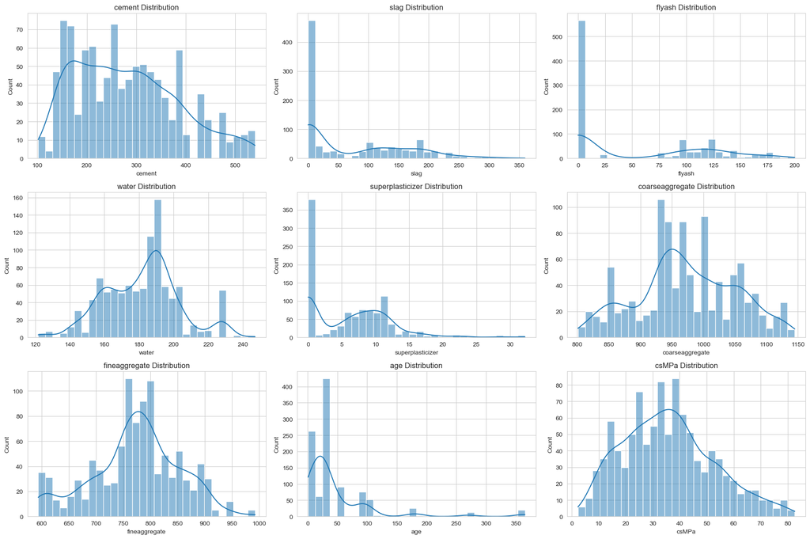

```python
import seaborn as sns
import matplotlib.pyplot as plt

def plot_all_distributions(data):
    sns.set_style("whitegrid")
    columns = data.columns
    fig, axes = plt.subplots(3, 3, figsize=(18, 12))
    axes = axes.flatten()
    for i, col in enumerate(columns):
        sns.histplot(data=data,x=col,kde=True,bins=30,ax=axes[i])
        axes[i].set_title(f"{col} Distribution", fontsize=12)
        axes[i].set_xlabel(col, fontsize=10)
        axes[i].set_ylabel("Count", fontsize=10)

    plt.tight_layout()
    plt.show()

plot_all_distributions(data)
```

## 相关性分析

相关性分析结果表明，水泥含量（cement）与抗压强度呈正相关，而水（water）与抗压强度呈负相关，不同材料对强度的影响程度存在差异。

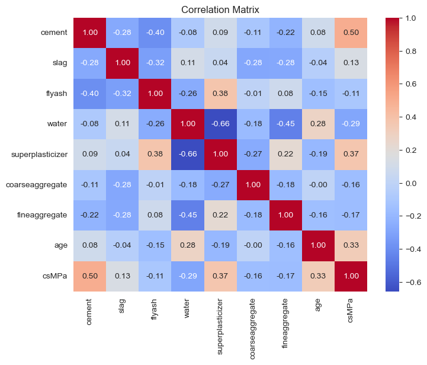

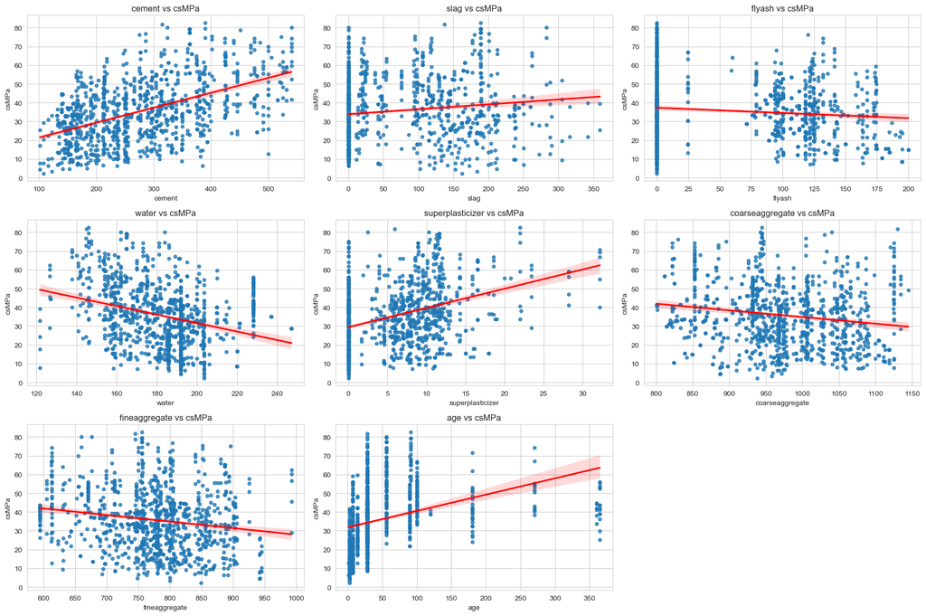

```python
corr = data.corr()
plt.figure(figsize=(8,6))
sns.heatmap(corr,annot=True,cmap="coolwarm",fmt=".2f")
plt.title("Correlation Matrix")
plt.show()
def plot_scatter_with_reg(data, target="csMPa"):
    sns.set_style("whitegrid")
    features = data.columns.drop(target)
    fig, axes = plt.subplots(3, 3, figsize=(18, 12))
    axes = axes.flatten()
    for i, col in enumerate(features):
        sns.regplot(data=data,x=col,y=target,ax=axes[i],scatter_kws={"s": 20}, line_kws={"color": "red"})
        axes[i].set_title(f"{col} vs {target}")
    fig.delaxes(axes[-1])
    plt.tight_layout()
    plt.show()
plot_scatter_with_reg(data)
```

## 主成分分析

PCA通过对协方差矩阵进行特征分解，将原始特征转换为新的正交特征（主成分），以实现降维。前6个主成分已能够保留约97%以上的信息，因此选取6个主成分进行后续建模

```
各主成分方差贡献率：
 [0.28501242 0.17700935 0.16750988 0.12676986 0.1189385  0.09877443
 0.02223021 0.00375535]
累计方差贡献率：
 [0.28501242 0.46202177 0.62953165 0.75630151 0.87524001 0.97401444
 0.99624465 1.        ]
```

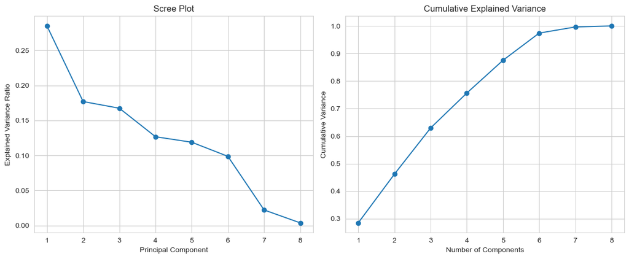

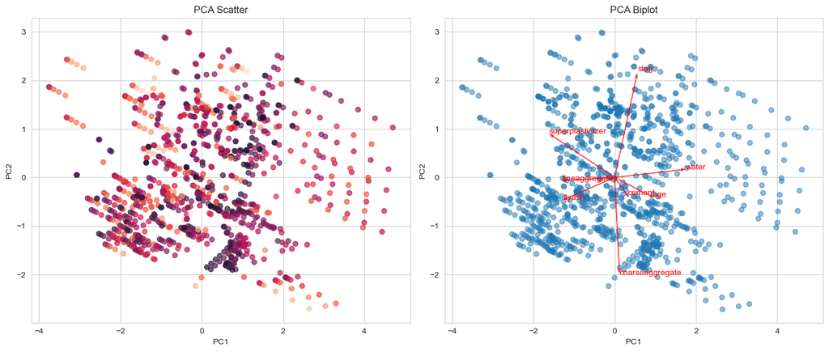

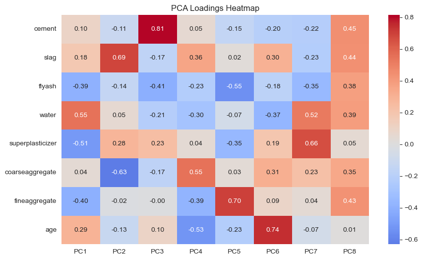

```python
import numpy as np
from sklearn.preprocessing import StandardScaler
from sklearn.decomposition import PCA
# 分离特征
X = data.drop("csMPa", axis=1)

# 标准化
scaler = StandardScaler()
X_scaled = scaler.fit_transform(X)

# PCA
pca = PCA()
X_pca = pca.fit_transform(X_scaled)

# 查看每个主成分解释的方差比例
explained_var = pca.explained_variance_ratio_
cum_explained_var = np.cumsum(explained_var)

print("各主成分方差贡献率：\n", explained_var)
print("累计方差贡献率：\n", cum_explained_var)
#查看每个主成分贡献了多少信息，以及累计贡献了多少信息
fig, axes = plt.subplots(1, 2, figsize=(12, 5))
# 左图：Scree Plot
axes[0].plot(range(1, len(explained_var) + 1), explained_var, marker='o')
axes[0].set_title("Scree Plot")
axes[0].set_xlabel("Principal Component")
axes[0].set_ylabel("Explained Variance Ratio")
# 右图：累计方差
axes[1].plot(range(1, len(cum_explained_var) + 1), cum_explained_var, marker='o')
axes[1].set_title("Cumulative Explained Variance")
axes[1].set_xlabel("Number of Components")
axes[1].set_ylabel("Cumulative Variance")
plt.tight_layout()
plt.show()
fig, axes = plt.subplots(1, 2, figsize=(14, 6))
#查看前两个主成分的散点图和双标图
# 左：PCA散点图
scatter = axes[0].scatter(X_pca[:, 0],X_pca[:, 1],c=data["csMPa"],alpha=0.7)
axes[0].set_title("PCA Scatter")
axes[0].set_xlabel("PC1")
axes[0].set_ylabel("PC2")

# 右：Biplot
axes[1].scatter(X_pca[:, 0], X_pca[:, 1], alpha=0.5)
for i, feature in enumerate(X.columns):
    axes[1].arrow(0, 0,loadings.iloc[i, 0] * 3,loadings.iloc[i, 1] * 3,color='red',alpha=0.7,head_width=0.05)
    axes[1].text(loadings.iloc[i, 0] * 3.2,loadings.iloc[i, 1] * 3.2,feature,color='red')
axes[1].set_title("PCA Biplot")
axes[1].set_xlabel("PC1")
axes[1].set_ylabel("PC2")

plt.tight_layout()
plt.show()
#查看每个主成分的载荷（
loadings = pd.DataFrame(pca.components_.T,index=X.columns,columns=[f"PC{i+1}" for i in range(X.shape[1])])
plt.figure(figsize=(10, 6))
sns.heatmap(loadings, annot=True, cmap="coolwarm", center=0, fmt=".2f")
plt.title("PCA Loadings Heatmap")
plt.show()
```

## 线性回归

```
===== 原始特征模型 =====
Train R2: 0.6181905004215971
Test R2 : 0.5037418272955774
Train MSE: 117.45245610387944
Test MSE : 75.74392466040452

===== PCA模型 =====
Train R2: 0.5934082901105865
Test R2 : 0.1612608795699041
Train MSE: 125.07597377938289
Test MSE : 128.01681915157096
```

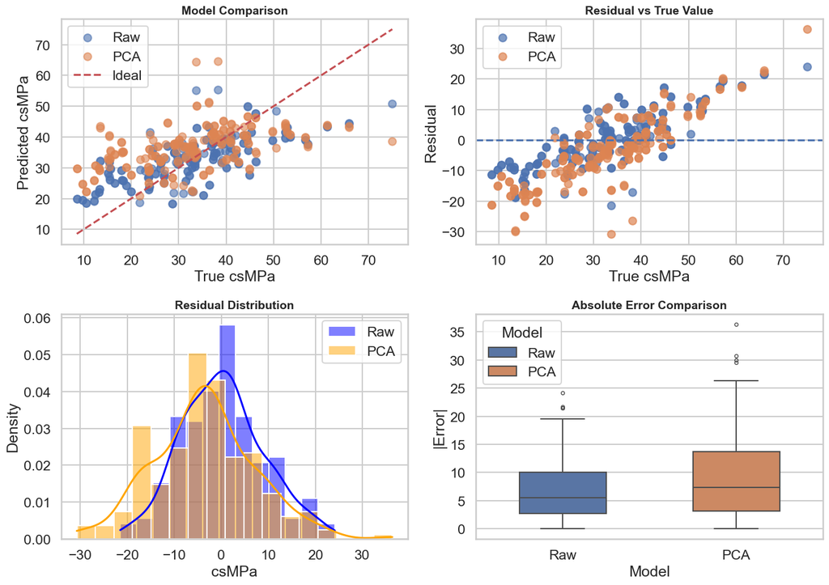

```python
from sklearn.linear_model import LinearRegression
from sklearn.metrics import r2_score, mean_squared_error

X = data.drop("csMPa", axis=1)
y = data["csMPa"]

# 按顺序划分数据（80%训练，20%测试）
split_idx = int(0.8 * len(data))
X_train = X.iloc[:split_idx]
X_test  = X.iloc[split_idx:]

y_train = y.iloc[:split_idx]
y_test  = y.iloc[split_idx:]

#  数据预处理（标准化）
scaler = StandardScaler()
X_train_scaled = scaler.fit_transform(X_train)
X_test_scaled  = scaler.transform(X_test)

#  PCA降维（6个主成分）
pca = PCA(n_components=6)
X_train_pca = pca.fit_transform(X_train_scaled)
X_test_pca  = pca.transform(X_test_scaled)

# 模型1：原始特征回归
model_raw = LinearRegression()
model_raw.fit(X_train_scaled, y_train)

y_pred_train_raw = model_raw.predict(X_train_scaled)
y_pred_test_raw  = model_raw.predict(X_test_scaled)

#  模型2：PCA回归
model_pca = LinearRegression()
model_pca.fit(X_train_pca, y_train)

y_pred_train_pca = model_pca.predict(X_train_pca)
y_pred_test_pca  = model_pca.predict(X_test_pca)

# 评价指标
print("===== 原始特征模型 =====")
print("Train R2:", r2_score(y_train, y_pred_train_raw))
print("Test R2 :", r2_score(y_test, y_pred_test_raw))
print("Train MSE:", mean_squared_error(y_train, y_pred_train_raw))
print("Test MSE :", mean_squared_error(y_test, y_pred_test_raw))

print("\n===== PCA模型 =====")
print("Train R2:", r2_score(y_train, y_pred_train_pca))
print("Test R2 :", r2_score(y_test, y_pred_test_pca))
print("Train MSE:", mean_squared_error(y_train, y_pred_train_pca))
print("Test MSE :", mean_squared_error(y_test, y_pred_test_pca))


# 残差
residual_raw = y_test - y_pred_test_raw
residual_pca = y_test - y_pred_test_pca

# 绝对误差
abs_error_raw = np.abs(residual_raw)
abs_error_pca = np.abs(residual_pca)

fig, axes = plt.subplots(2, 2, figsize=(14, 10))

#  Model Comparison
axes[0,0].scatter(y_test, y_pred_test_raw, alpha=0.6, label="Raw")
axes[0,0].scatter(y_test, y_pred_test_pca, alpha=0.6, label="PCA")

axes[0,0].plot([y_test.min(), y_test.max()],
               [y_test.min(), y_test.max()],
               'r--', label="Ideal")

axes[0,0].set_title("Model Comparison",fontsize=14, weight="bold")
axes[0,0].set_xlabel("True csMPa")
axes[0,0].set_ylabel("Predicted csMPa")
axes[0,0].legend()


# Residual Scatter
axes[0,1].scatter(y_test, residual_raw, alpha=0.7, label="Raw")
axes[0,1].scatter(y_test, residual_pca, alpha=0.7, label="PCA")
axes[0,1].axhline(0, linestyle='--')
axes[0,1].set_title("Residual vs True Value",fontsize=14, weight="bold")
axes[0,1].set_xlabel("True csMPa")
axes[0,1].set_ylabel("Residual")
axes[0,1].legend()


# Residual Distribution
sns.histplot(residual_raw, kde=True, ax=axes[1,0], color="blue", label="Raw", stat="density")
sns.histplot(residual_pca, kde=True, ax=axes[1,0], color="orange", label="PCA", stat="density")
axes[1,0].set_title("Residual Distribution",fontsize=14, weight="bold")
axes[1,0].legend()


# Boxplot
error_df = pd.DataFrame({
    "Absolute Error": np.concatenate([abs_error_raw, abs_error_pca]),
    "Model": ["Raw"] * len(abs_error_raw) + ["PCA"] * len(abs_error_pca)
})
sns.set(style="whitegrid", context="talk")
sns.boxplot(data=error_df,x="Model",y="Absolute Error",hue="Model",palette=["#4C72B0", "#DD8452"],width=0.5,linewidth=1.5,fliersize=4,legend=True,ax=axes[1,1])
axes[1,1].set_title("Absolute Error Comparison", fontsize=14, weight="bold")
axes[1,1].set_ylabel("|Error|")

plt.tight_layout()
plt.show()
```

图1：原始模型的预测结果更接近理想对角线，而PCA模型存在更明显偏离，说明原始模型拟合效果更好

图3：原始模型残差分布更加集中，而PCA模型分布更分散，说明其误差更大且稳定性较差

图4：从箱线图可以看出，原始模型的绝对误差中位数更低，且分布更集中，而PCA模型误差更大且存在更多离群点，说明原始特征模型在预测精度和稳定性方面均优于PCA模型。

本实验通过对比原始特征模型与PCA降维模型，发现尽管PCA能够有效降低特征维度并减少多重共线性，但由于其不考虑目标变量信息，在降维过程中可能丢失关键特征信息，导致预测性能下降。因此，在本数据集上，原始特征线性回归模型表现优于PCA模型